# Bremer County

Welcome to the Bremer County COVID-19 Data Page.

## Summary

2021-11-17: 271 active cases in Bremer County, IA today with 3 hospitalized. If the current infection trends continue, in 4 weeks we will have 476 active cases.

If you are in a group of 15 random people in Bremer County there is a 56.56% chance someone in the group is positive. One in 353 people in Bremer County has died of COVID-19.

In the last 7 days: 119 new positive cases (record), 0 new death(s) and 157 tests.

One year ago, we had 915 active cases and 38 new positive patients in Bremer County.

982 active cases in Black Hawk County, IA today with 14 hospitalized. If the current infection trends continue, in 4 weeks we will have 1436 active cases. If you are in a group of 15 people in Black Hawk County there is a 43.56% chance someone in the group is positive. One in 354 people in Black Hawk County has died of COVID-19.

In the last 7 days: 359 new positive cases, 3 new death(s) and 760 new people tested.

One year ago, we had 4009 active cases and 166 new positive patients in Black Hawk County.

192 active cases in Butler County, IA today with 6 hospitalized. If the current infection trends continue, in 4 weeks we will have 276 active cases. If you are in a group of 15 people in Butler County there is a 64.37% chance someone in the group is positive. One in 344 people in Butler County has died of COVID-19.

In the last 7 days: 69 new positive cases, 1 new death(s) and 113 new people tested.

One year ago, we had 351 active cases and 19 new positive patients in Butler County.

[output not shown]

[output not shown]

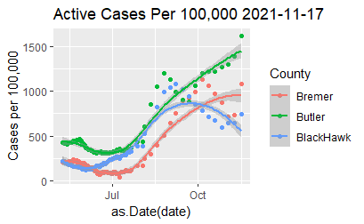

Here is the latest information availible as of 2021-11-17 :

|  | 363 |
| --- | --- |
| Positive | 3855.00 |
| Recovered | 3513.00 |
| Deaths | 71.00 |
| Tested | 15673.00 |
| Hospitalized | 3.00 |
| Active | 271.00 |
| New.Pos | 119.00 |
| New.Test | 157.00 |
| New.Rec | 32.00 |
| New.Deaths | 0.00 |
| Frac.Pos | 0.76 |

|  | date | Positive | Recovered | Deaths | Tested | Hospitalized | Active |
| --- | --- | --- | --- | --- | --- | --- | --- |
| 74 | 2020-05-29 | 69 | 59 | 6 | NA | NA | 4 |
| 75 | 2020-05-30 | 70 | 59 | 6 | NA | NA | 5 |
| 76 | 2020-06-01 | 70 | 59 | 6 | NA | NA | 5 |
| 77 | 2020-06-02 | 69 | 59 | 6 | NA | NA | 4 |
| 78 | 2020-06-03 | 69 | 59 | 6 | NA | NA | 4 |
| 79 | 2020-06-04 | 70 | 61 | 6 | NA | NA | 3 |
| 80 | 2020-06-05 | 71 | 61 | 6 | NA | NA | 4 |
| 81 | 2020-06-06 | 71 | 61 | 6 | NA | NA | 4 |
| 82 | 2020-06-07 | 71 | 61 | 6 | NA | NA | 4 |
| 83 | 2020-06-08 | 74 | 61 | 6 | NA | NA | 7 |
| 84 | 2020-06-09 | 74 | 63 | 6 | NA | NA | 5 |
| 85 | 2020-06-10 | 74 | 63 | 6 | NA | NA | 5 |
| 86 | 2020-06-11 | 74 | 64 | 6 | NA | NA | 4 |
| 87 | 2020-06-12 | 74 | 65 | 6 | NA | NA | 3 |
| 88 | 2020-06-13 | 74 | 65 | 6 | NA | NA | 3 |
| 89 | 2020-06-14 | 74 | 65 | 6 | NA | NA | 3 |
| 90 | 2020-06-15 | 74 | 66 | 6 | NA | NA | 2 |
| 91 | 2020-06-16 | 74 | 66 | 6 | NA | NA | 2 |
| 92 | 2020-06-17 | 75 | 66 | 6 | NA | NA | 3 |
| 93 | 2020-06-18 | 81 | 66 | 6 | NA | NA | 9 |
| 94 | 2020-06-19 | 81 | 66 | 6 | NA | NA | 9 |
| 95 | 2020-06-20 | 81 | 68 | 6 | NA | NA | 7 |
| 96 | 2020-06-21 | 82 | 68 | 6 | NA | NA | 8 |
| 97 | 2020-06-22 | 82 | 68 | 6 | NA | NA | 8 |
| 98 | 2020-06-23 | 82 | 68 | 6 | NA | NA | 8 |
| 99 | 2020-06-24 | 85 | 69 | 6 | NA | NA | 10 |
| 100 | 2020-06-25 | 85 | 70 | 6 | NA | NA | 9 |
| 101 | 2020-06-26 | 85 | 70 | 6 | NA | NA | 9 |
| 102 | 2020-06-27 | 85 | 70 | 6 | NA | NA | 9 |
| 103 | 2020-06-28 | 85 | 70 | 6 | NA | NA | 9 |

[output cut: 395 more lines]